# IndiMap plots and analyses

This report will

- compile indicator profiles `"/data/indicatorProfiles/"` and publication profiles `"/data/pulicationProfiles/"` into long format
- Perform resampling to craete dummy data
- Create plots and summary statistics

# Packages

Here are the required packages

```r
install.packages(c("tidyverse", "DT"))
```

```r
library(targets)
library(tidyverse)
library(DT)
```

```r
tar_option_set(packages = c("tidyverse", "dplyr", "purrr", "readr", "tidyr", "ggplot2")) # I had to mention dplyr, purrr ect even though they are included in tidyverse.
options(tidyverse.quiet = TRUE)
```

```
#> Establish _targets.R and _targets_r/globals/setup-targets.R.
```

Here’s a function to read all the CSV’s and compile them in a long format. We also take the file name and add that to the data set.

```r
##| tar_interactive: FALSE
compile_profiles <- function(files) {
  files |>
    set_names(basename) |>
    map(read.csv) %>%
  list_rbind(names_to = "fileName") |>
  tidyr::pivot_wider(names_from = parameter, values_from = value)}
```

```
#> Establish _targets.R and _targets_r/globals/compile.R.
```

# Targets

## Import data

Our first target reads in all the file names in `data/publicationProfiles` and stores them in a single object (`ppls`), which we can then monitor for updates.

```r
##| tar_interactive: FALSE
tar_target(ppls,
           list.files("data/publicationProfiles", full.names = T),
           cue = tar_cue(mode = "thorough"),
           format="file",
           packages = "tidyverse")
```

```
#> Establish _targets.R and _targets_r/targets/pp-ls.R.
```

Then we import these files and compile them into long format using `compile_profiles()`.

```r
##| tar_interactive: FALSE
tar_target(publications_imported, compile_profiles(ppls),
           packages = "tidyverse")
```

```
#> Establish _targets.R and _targets_r/targets/pp-import.R.
```

Then the same for `data/indicatorProfiles`.

```r
##| tar_interactive: FALSE
tar_target(ipls,
           list.files("data/indicatorProfiles", full.names = T),
           cue = tar_cue(mode = "thorough"),
           format="file",
           packages = "tidyverse")
```

```
#> Establish _targets.R and _targets_r/targets/ip-ls.R.
```

Then we import these files

```r
##| tar_interactive: FALSE
tar_target(indicators_imported, compile_profiles(ipls),
           packages = "tidyverse")
```

```
#> Establish _targets.R and _targets_r/targets/ip-import.R.
```

## Create dummy data

Let’s make a function to re-sample `import_indicators` and populate a dummy data set which we can use to write generic code with.

To scramble these we need a separate approach compared to just re-sampling rows.

Here is a function to take a vector (data frame column) of length x, make it longer based on a deliminator to become x+z, sample to length of x, and sample some again to combine and make multiple choice fields.

```r
scramble_ms <- function(x) {
  vector <- x |>
    as.data.frame() |>
    separate_longer_delim(cols = x, delim=" | ") |>
    distinct()
  long <- sample(vector[,1], 150, replace = T)
  # add some double values
  secondvalue <- sample(long, 20) # in 20 places
  secondvalue <- secondvalue[secondvalue!= ""] # rm blanks
  rows <- sample(1:150, 20, replace = F) # pick random row(vector) positions
  long[rows] <-  paste(long[rows], secondvalue, sep= " | ") # paste second value
  long <- str_replace(long, "^.[|].", "") # rm leading " | "
  return(long)
  }
```

```
#> Establish _targets.R and _targets_r/globals/scramble_ms.R.
```

Now we can use this function inside `mutate(across())`.

```r
##| tar_interactive: FALSE
scramble <- function(data) {
  #These are the multiple choice (mc) columns
  mc <- c("iContinent", "iCountry", "iET", "dOrigin", "iBiome")
  # resample to get 150 rows
  data[sample(1:nrow(data), 150, replace = T),] |>
    # replace the mc columns
    mutate(across(any_of(mc),scramble_ms))
}
```

```
#> Establish _targets.R and _targets_r/globals/scramble.R.
```

```r
tar_target(indicators_dummyData, scramble(indicators_imported))
```

```
#> Establish _targets.R and _targets_r/targets/dummyData.R.
```

#Plots Here are function to plot data

```r
##| tar_interactive: FALSE

create_bar <- function(data, x) {
  data |>
    separate_longer_delim(x, " | ") |>
    ggplot() +
    geom_bar(aes_string(x = x),
             fill="#FFDB6D",
             colour="grey30") +
    theme_minimal(18)+
    coord_flip()+
    theme(axis.title.y = element_blank(),
          axis.title.x = element_blank())
}
```

```
#> Establish _targets.R and _targets_r/globals/barplot.R.
```

And here are the figure targets

```r
tar_target(barPlot_country, create_bar(indicators_dummyData, "iCountry"),
           packages = "tidyverse")
```

```
#> Establish _targets.R and _targets_r/targets/barPlot_country.R.
```

```r
tar_target(barPlot_continent, create_bar(indicators_dummyData, "iContinent"),
           packages = "tidyverse")
```

```
#> Establish _targets.R and _targets_r/targets/barPlot_continent.R.
```

# Pipeline

If you ran all the `{targets}` chunks in non-interactive mode, then your R scripts are set up to run the pipeline.

```r
tar_make()
```

[output not shown]

# Output

## Raw data tables

|  | fileName | githubUser | pTitle | pRayyanID | pOrigin | pID | pBibliography | pRedundant | pType | pComment | pJournal | pDirective | pAssessment | pAssessmentYear | pEAAextent | pAggregation | pAggregationRemark | pTotalNumberOfIndicators | pEAAarea |
| --- | --- | --- | --- | --- | --- | --- | --- | --- | --- | --- | --- | --- | --- | --- | --- | --- | --- | --- | --- |
| 1 | Test1-pProfile_2023-11-01 13-58-34.233358.csv | anders-kolstad | Here's a great title | 123456789 | Systematic search | 04ee103e-a0de-4fc2-8ce8-fea342a9990e | Full refffffffffffffffff | Unique | Peer-reviewed article | A great long report with lots of confusing stuff in it | Here's a great high ranking journal name | Not relevant | Assessment | 2022 | 0 - unknown | 0 | - |  |  |
| 2 | test10-pProfile_2023-11-02 13-11-14.000413.csv | AndersPanders | title title | 12354123 | Opportunistic | a67bd45d-9431-4991-b735-1533b2eb58bd | www.nnnnnnn.no | Unique | Unpublished | Obs, level of aggregation is blank. |  |  | Assessment | 2023 | 7 - project-area |  |  |  | 5041561 |
| 3 | Test2-pProfile_2023-11-01 14-01-44.213598.csv | anders-kolstad | Here's another great title | 1234567899 | SEEA EA list | 04ee103e-a0de-4fc2-8ce8-fea342a9990eblablabla | Full refffffffffffffffff 1 | Possibly redundant | Book | A great long report with lots of confusing stuff in it |  | Not relevant \| EU Birds Directive | Assessment | 2021 | 1 - global | 1 | Turtle index |  |  |
| 4 | Test3-pProfile_2023-11-02 12-40-16.792013.csv | ola-nordman | Yet another great title | 123654123 | SEEA EA list | 93d97c8e-b97d-4573-a570-7b3bd2e293ef | refrefrefrefrerf | Redundant | Peer-reviewed article | A great way to spend an evening | ECOLOGICAL MODELLING | Not relevant \| EU Birds Directive | Assessment | 1984 | 2 - continent | 2 | Area weighted mean aggregated to mapping units | 10 |  |
| 5 | test4-pProfile_2023-11-02 12-45-27.242683.csv | kari-normann | Oh, a duplicate title! | 123 | Opportunistic | c3cbdd75-fcde-4bb5-a25b-71b24f91b845 |  | Unique | Peer-reviewed article | NA | HYDROBIOLOGIA | Not relevant \| EU Habitats Directive | Assessment | 2000 | 3 - multi-national | 3 | Forest stands | 4 |  |
| 6 | test5-pProfile_2023-11-02 12-49-25.310028.csv | anders-kolstad | Oh, a duplicate title! | 1235153 | Systematic search | b80e6250-4b9c-4b1a-9ce1-88f336dd16be | bjhbhdbvslvbhlvdhbl hg uh uh hu hu h j hj hj | Unique | Peer-reviewed article | Some comment here | PLOS ONE | EU Birds Directive \| EU Habitats Directive | Assessment | 2023 | 4 - country | 4 | All forests | 2 |  |
| 7 | Test6-pProfile_2023-11-02 12-58-44.288243.csv | anders-kolstad | 15344 cbsahdcbsa | 4564879 | Systematic search | ed4b877f-c125-47ad-af1e-d8f99c93d5f7 | bvybcsd,d,d,,d,d,d | Possibly redundant | Book | So looooong. Look for error in |  | Not relevant | Assessment | 201 | 5 - region | 5 | none | 2 |  |
| 8 | test7-pProfile_2023-11-02 12-59-49.516887.csv | anders-kolstad | title ohoi | 987654321 | SEEA EA list | 81c16fea-00c4-4d5c-990f-6713ebc884de | uiossijosijosij | Unique | Book chapter | NA |  | Not relevant | Not an assessment |  |  |  |  |  |  |
| 9 | test8-pProfile_2023-11-02 13-04-18.961618.csv | anders-kolstad | Moby dick | 545464213 | Systematic search | e01de13b-4d7e-4820-ae2a-48df895ea611 | blablablabalbal | Unique | Rapport | Note nonsensical |  | Not relevant | Assessment | 1950 | 6 - local | 2 |  | 5 |  |
| 10 | test9-pProfile_2023-11-02 13-07-10.525437.csv | Anders-Panders | really long title really long title really long title really long title really long title really long title really long title really long title really long title really long title really long title re… | 123541 | Systematic search | 4e75fb83-6197-482c-89c9-0dfcf9c5e269 | gfdgfdgdfgdfg | Unique | Web resource | NA |  | Not relevant | Assessment | 1950 | 6 - local | 1 |  |  | 233 |

|  | fileName | iID | pTitle | githubUser | iName | iRedundant | iRedundantRemarks | iRedundantReferences | iContinent | iCountry | iLowerGeography | iLatitude | iLongitude | iET | iETlink | dName | dReference | dOrigin | dSpatialCoverage | iDescriptionSnippet | iDescription | iSpatialExtent | iSpatialResolution | iTemporalCoverage | iMap | iYear | iBiome | iSubIndex | iModelling | … |
| --- | --- | --- | --- | --- | --- | --- | --- | --- | --- | --- | --- | --- | --- | --- | --- | --- | --- | --- | --- | --- | --- | --- | --- | --- | --- | --- | --- | --- | --- | --- |
| 1 | TestA-iProfile_2023-11-02 10-03-27.651839.csv | 584bd226-acf1-4060-8d11-a12c8e5e0bea | Here's a great title | anders-kolstad | Crop diversity | Unique |  |  | Europe |  | EU |  |  | 2 - Cropland | fo - Field observations | Elaboration of data from EUROSTAT and from different National Institutes of Statistics | https://agri4cast.jrc.ec.europa.eu/DataPortal/Index.aspx?o=d | OT - others or unsure | 1 - complete | Crop diversity in agroecosystems is a measure of the variety of different crops in a given spatial unit. In general, higher crop diversity is considered to be beneficial for soil quality, to contrast … | Crop diversity in agroecosystems is a measure of the variety of different crops in a given spatial unit. | 3 - multi-national | 5 - region | 17 | Yes | 2017 | T7 - Intensive land-use systems | No |  | … |
| 2 | TestB-iProfile_2023-11-02 13-43-01.297135.csv | 92e1bcb2-0a84-431d-b499-80e5036e406d | title title | anders-kolstad | Deadwood | Unique |  |  | Africa \| Europe | AS \| AZ \| BL \| BO |  |  |  | 4 - Forest and woodland | fo - Field observations | fdsfdsfds | fdsfdsfdsf | RS - remotely sensed | 0 - NA | ffffffffgggggggghnjjjjjjjjjj | dsfgwefgergergg | 0 - unknown | 0 - unknown | 1 | No | 2022 | T1 - Tropical-subtropical forests \| T2 - Temperate-boreal forests &amp; woodlands | No | No | … |
| 3 | TestC-iProfile_2023-11-02 14-08-22.932263.csv | 938459ea-9b49-4367-83c1-2e46b2fd08af | Yet another great title | anders-kolstad | Percentage of forest covered by Natura 2000 (%) | Unique |  |  | Europe |  |  |  |  | 5 - Heathland and shrub \| 6 - Sparsely vegetated ecosystems | so - Spatial overlay | gdsgsg | gsgs | CS - crowd sourced | 3 - oppurtunistic or sporadic | hrghgfhf | hgfhghfghfg | 3 - multi-national | 3 - multi-national | 6 | Not by itself, but as part of an aggregated index | 1900 | T1 - Tropical-subtropical forests \| T2 - Temperate-boreal forests &amp; woodlands \| T3 - Shrublands &amp; shrubby woodlands | No | Unclear | … |
| 4 | TestD-iProfile_2023-11-03 11-19-26.914474.csv | be7ee2bc-552b-4e74-b0eb-0e8dd3a66e72 | Here's another great title | anders | Percentage of forest covered by Natura 2000 (%) | Unique |  |  | Europe |  |  |  |  | 4 - Forest and woodland | so - Spatial overlay | Corine and Natura2000 | https://www.eea.europa.eu/data-and-maps/data/corine-land-cover-accounting-layers#tab-european-data, https://www.eea.europa.eu/dataand-maps/data/natura-10 | RS - remotely sensed \| OT - others or unsure | 1 - complete | This indicator aims to evaluate how the percentage of forest protected by Natura 2000 site has being changed against time. The changes could be due to changes of ecosystem extent, for example due to a… | This indicator aims to evaluate how the percentage of forest protected by Natura 2000 site has being changed against time. | 3 - multi-national | 4 - country |  |  | 2018 | T2 - Temperate-boreal forests &amp; woodlands | No | No | … |
| 5 | TestE-iProfile_2023-11-03 13-15-15.602268.csv | bd8b22df-8fb6-4cbe-a7cf-22c3d08a1924 | Moby dick | anders | Indicator X | Possibly redundant | fgfdgdf | fdhdghd | South America | AW |  |  |  | 1 - Settlements and other artificial areas | na - not applicable | dataset A |  |  |  | jjfgj | jkthjhjhfjh | 2 - continent | 2 - continent | 1 | Yes | 1900 | T7 - Intensive land-use systems | Yes | Yes | … |
| 6 | TestF-iProfile_2023-11-03 13-28-33.918646.csv | 7ba8484f-e70f-4575-b119-c17ab3e9f6f2 | really long title really long title really long title really long title really long title really long title really long title really long title really long title really long title really long title re… | anders | name here | Redundant | dfedqwdwqdw | dwdwdwd |  | AO \| AQ \| AR \| AS \| AT \| AU \| AW \| AX \| BA \| BG \| BM \| BN \| BO \| BQ \| BR \| BS \| BT \| BV | hh |  |  | 3 - Grassland \| 7 - Inland wetlands | dm - Derived from maps | ctkvyujvgy | bhlbhkbh | EO - expert opinion | 4 - unknown | gfegergerg | egergergre | 5 - region | 5 - region | 5 | No | 2020 | T4 - Savannas and grasslands | Yes | Yes | … |
| 7 | TestG-iProfile_2023-11-03 13-35-20.586885.csv | 53ec56c0-7b34-46ba-bf0a-673183b1f217 | Here's a great title | anders-kolstad | my great indicator | Unique |  |  | South America |  | None |  |  | 5 - Heathland and shrub | na - not applicable | no name | no ref | RS - remotely sensed \| MP - established monitoring program \| FS - field sampling \| CS - crowd sourced \| EO - expert opinion \| OT - others or unsure | 1 - complete | fgfdsgfdsg | fdsgdfsgfdgdf | 6 - local | 6 - local | 1 | Yes | 1903 | T1 - Tropical-subtropical forests \| T2 - Temperate-boreal forests &amp; woodlands \| T3 - Shrublands &amp; shrubby woodlands \| T4 - Savannas and grasslands \| T5 - Deserts and semi-deserts \| T6 - P… | No | No | … |
| 8 | TestH-iProfile_2023-11-03 13-38-16.638584.csv | 6b4f8d31-6be3-4bd6-ad47-4eb1dc7a91fd | really long title really long title really long title really long title really long title really long title really long title really long title really long title really long title really long title re… | annders | name name name | Unique |  |  | Africa \| Antarctica \| Asia \| Australia \| Europe \| North America \| South America | NO |  |  |  | 2 - Cropland | un - unknown |  |  | RS - remotely sensed \| MP - established monitoring program \| FS - field sampling \| CS - crowd sourced \| EO - expert opinion \| OT - others or unsure | 1 - complete |  |  | 7 - project-area | 7 - project-area | 100 | Not by itself, but as part of an aggregated index | 2023 | T6 - Polar-alpine | Unclear | Unclear | … |

|  | fileName | iID | pTitle | githubUser | iName | iRedundant | iRedundantRemarks | iRedundantReferences | iContinent | iCountry | iLowerGeography | iLatitude | iLongitude | iET | iETlink | dName | dReference | dOrigin | dSpatialCoverage | iDescriptionSnippet | iDescription | iSpatialExtent | iSpatialResolution | iTemporalCoverage | iMap | iYear | iBiome | iSubIndex | iModelling | … |
| --- | --- | --- | --- | --- | --- | --- | --- | --- | --- | --- | --- | --- | --- | --- | --- | --- | --- | --- | --- | --- | --- | --- | --- | --- | --- | --- | --- | --- | --- | --- |
| 1 | TestD-iProfile_2023-11-03 11-19-26.914474.csv | be7ee2bc-552b-4e74-b0eb-0e8dd3a66e72 | Here's another great title | anders | Percentage of forest covered by Natura 2000 (%) | Unique |  |  | South America | BO |  |  |  | 5 - Heathland and shrub | so - Spatial overlay | Corine and Natura2000 | https://www.eea.europa.eu/data-and-maps/data/corine-land-cover-accounting-layers#tab-european-data, https://www.eea.europa.eu/dataand-maps/data/natura-10 | MP - established monitoring program | 1 - complete | This indicator aims to evaluate how the percentage of forest protected by Natura 2000 site has being changed against time. The changes could be due to changes of ecosystem extent, for example due to a… | This indicator aims to evaluate how the percentage of forest protected by Natura 2000 site has being changed against time. | 3 - multi-national | 4 - country |  |  | 2018 | T6 - Polar-alpine | No | No | … |
| 2 | TestA-iProfile_2023-11-02 10-03-27.651839.csv | 584bd226-acf1-4060-8d11-a12c8e5e0bea | Here's a great title | anders-kolstad | Crop diversity | Unique |  |  | South America | BM \| BR | EU |  |  | 5 - Heathland and shrub | fo - Field observations | Elaboration of data from EUROSTAT and from different National Institutes of Statistics | https://agri4cast.jrc.ec.europa.eu/DataPortal/Index.aspx?o=d | CS - crowd sourced | 1 - complete | Crop diversity in agroecosystems is a measure of the variety of different crops in a given spatial unit. In general, higher crop diversity is considered to be beneficial for soil quality, to contrast … | Crop diversity in agroecosystems is a measure of the variety of different crops in a given spatial unit. | 3 - multi-national | 5 - region | 17 | Yes | 2017 | T1 - Tropical-subtropical forests | No |  | … |
| 3 | TestA-iProfile_2023-11-02 10-03-27.651839.csv | 584bd226-acf1-4060-8d11-a12c8e5e0bea | Here's a great title | anders-kolstad | Crop diversity | Unique |  |  |  | AW \| AO | EU |  |  | 2 - Cropland | fo - Field observations | Elaboration of data from EUROSTAT and from different National Institutes of Statistics | https://agri4cast.jrc.ec.europa.eu/DataPortal/Index.aspx?o=d | EO - expert opinion | 1 - complete | Crop diversity in agroecosystems is a measure of the variety of different crops in a given spatial unit. In general, higher crop diversity is considered to be beneficial for soil quality, to contrast … | Crop diversity in agroecosystems is a measure of the variety of different crops in a given spatial unit. | 3 - multi-national | 5 - region | 17 | Yes | 2017 | T3 - Shrublands &amp; shrubby woodlands | No |  | … |
| 4 | TestC-iProfile_2023-11-02 14-08-22.932263.csv | 938459ea-9b49-4367-83c1-2e46b2fd08af | Yet another great title | anders-kolstad | Percentage of forest covered by Natura 2000 (%) | Unique |  |  | North America | BO |  |  |  | 6 - Sparsely vegetated ecosystems \| 7 - Inland wetlands | so - Spatial overlay | gdsgsg | gsgs | FS - field sampling | 3 - oppurtunistic or sporadic | hrghgfhf | hgfhghfghfg | 3 - multi-national | 3 - multi-national | 6 | Not by itself, but as part of an aggregated index | 1900 | T2 - Temperate-boreal forests &amp; woodlands \| T5 - Deserts and semi-deserts | No | Unclear | … |
| 5 | TestB-iProfile_2023-11-02 13-43-01.297135.csv | 92e1bcb2-0a84-431d-b499-80e5036e406d | title title | anders-kolstad | Deadwood | Unique |  |  | Asia | AO \| AW |  |  |  | 4 - Forest and woodland \| 4 - Forest and woodland | fo - Field observations | fdsfdsfds | fdsfdsfdsf | CS - crowd sourced | 0 - NA | ffffffffgggggggghnjjjjjjjjjj | dsfgwefgergergg | 0 - unknown | 0 - unknown | 1 | No | 2022 | T7 - Intensive land-use systems | No | No | … |
| 6 | TestH-iProfile_2023-11-03 13-38-16.638584.csv | 6b4f8d31-6be3-4bd6-ad47-4eb1dc7a91fd | really long title really long title really long title really long title really long title really long title really long title really long title really long title really long title really long title re… | annders | name name name | Unique |  |  | Europe \| Europe | BS |  |  |  | 6 - Sparsely vegetated ecosystems | un - unknown |  |  | CS - crowd sourced | 1 - complete |  |  | 7 - project-area | 7 - project-area | 100 | Not by itself, but as part of an aggregated index | 2023 | T5 - Deserts and semi-deserts | Unclear | Unclear | … |
| 7 | TestF-iProfile_2023-11-03 13-28-33.918646.csv | 7ba8484f-e70f-4575-b119-c17ab3e9f6f2 | really long title really long title really long title really long title really long title really long title really long title really long title really long title really long title really long title re… | anders | name here | Redundant | dfedqwdwqdw | dwdwdwd | South America \| Africa | BG | hh |  |  | 5 - Heathland and shrub | dm - Derived from maps | ctkvyujvgy | bhlbhkbh | CS - crowd sourced | 4 - unknown | gfegergerg | egergergre | 5 - region | 5 - region | 5 | No | 2020 | T2 - Temperate-boreal forests &amp; woodlands | Yes | Yes | … |
| 8 | TestG-iProfile_2023-11-03 13-35-20.586885.csv | 53ec56c0-7b34-46ba-bf0a-673183b1f217 | Here's a great title | anders-kolstad | my great indicator | Unique |  |  | Antarctica | AW | None |  |  | 4 - Forest and woodland \| 1 - Settlements and other artificial areas | na - not applicable | no name | no ref | OT - others or unsure | 1 - complete | fgfdsgfdsg | fdsgdfsgfdgdf | 6 - local | 6 - local | 1 | Yes | 1903 | T2 - Temperate-boreal forests &amp; woodlands \| T7 - Intensive land-use systems | No | No | … |
| 9 | TestD-iProfile_2023-11-03 11-19-26.914474.csv | be7ee2bc-552b-4e74-b0eb-0e8dd3a66e72 | Here's another great title | anders | Percentage of forest covered by Natura 2000 (%) | Unique |  |  | South America | BR |  |  |  | 5 - Heathland and shrub | so - Spatial overlay | Corine and Natura2000 | https://www.eea.europa.eu/data-and-maps/data/corine-land-cover-accounting-layers#tab-european-data, https://www.eea.europa.eu/dataand-maps/data/natura-10 | MP - established monitoring program | 1 - complete | This indicator aims to evaluate how the percentage of forest protected by Natura 2000 site has being changed against time. The changes could be due to changes of ecosystem extent, for example due to a… | This indicator aims to evaluate how the percentage of forest protected by Natura 2000 site has being changed against time. | 3 - multi-national | 4 - country |  |  | 2018 | T3 - Shrublands &amp; shrubby woodlands | No | No | … |
| 10 | TestA-iProfile_2023-11-02 10-03-27.651839.csv | 584bd226-acf1-4060-8d11-a12c8e5e0bea | Here's a great title | anders-kolstad | Crop diversity | Unique |  |  | Australia | BQ | EU |  |  | 1 - Settlements and other artificial areas | fo - Field observations | Elaboration of data from EUROSTAT and from different National Institutes of Statistics | https://agri4cast.jrc.ec.europa.eu/DataPortal/Index.aspx?o=d | EO - expert opinion | 1 - complete | Crop diversity in agroecosystems is a measure of the variety of different crops in a given spatial unit. In general, higher crop diversity is considered to be beneficial for soil quality, to contrast … | Crop diversity in agroecosystems is a measure of the variety of different crops in a given spatial unit. | 3 - multi-national | 5 - region | 17 | Yes | 2017 | UNK - Unknown or dont fit | No |  | … |

[output cut: 140 more lines]

# Figures

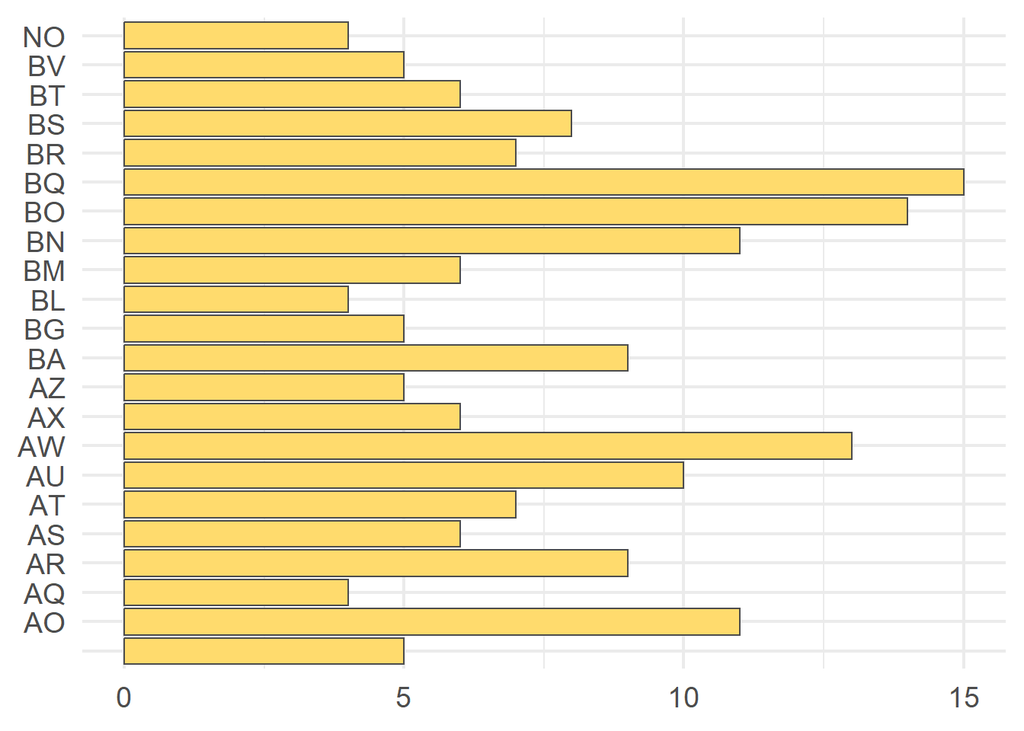

```r
tar_read(barPlot_country)
```

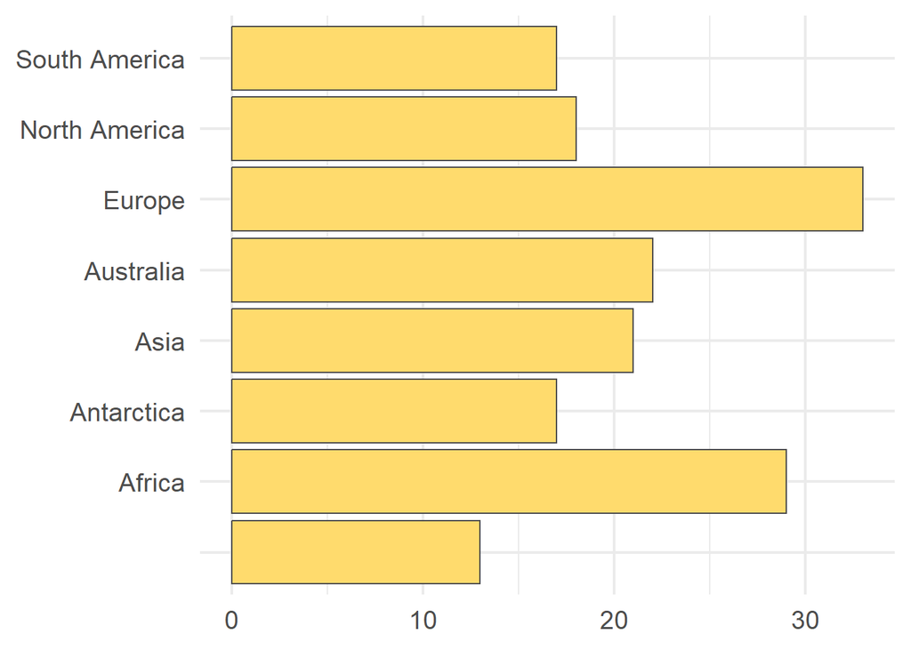

```r
tar_read(barPlot_continent)
```

## DAG

The `targets` dependency graph helps your readers understand the steps of your pipeline at a high level.

```r
tar_visnetwork()
```

[interactive chart not shown]